# Trabajo de Inferencia Causal: Datos de cartera de seguros

# 3 Selección de metodología: Caso 2, Experiencia.

Se utiliza el método matching para comparar entre grupos tratados y no tratados, con el objetivo de realizar una estimación del efecto causal de la variable tratamiento. Este método sirve para equiparar las características entre individuos tratados y no tratados, para que las diferencias entre ambos conjuntos pueda atribuirse a los tratamientos, y no tanto a las diferencias entre los valores de cada una de las muestras entre ambos conjuntos.

En este caso, se parean las muestras control con los tratados. Teniendo 18295 casos de no tratados (control), se parea el número de individuos tratados con observaciones no tratadas, en total 6705 emparejados, dejando sin emparejar 11590 individuos no tratados.

```r
## Matching EXPERIENCIA
m.ps.train.2 <- matchit(experiencia ~ Veh_val + veh_ant + Veh_cdin, method = "nearest",
    distance = "glm", data = data)

m.ps.train.2
```

```
A matchit object
 - method: 1:1 nearest neighbor matching without replacement
 - distance: Propensity score
             - estimated with logistic regression
 - number of obs.: 25000 (original), 13410 (matched)
 - target estimand: ATT
 - covariates: Veh_val, veh_ant, Veh_cdin
```

```r
summary(m.ps.train.2)
```

```
Call:
matchit(formula = experiencia ~ Veh_val + veh_ant + Veh_cdin,
    data = data, method = "nearest", distance = "glm")

Summary of Balance for All Data:
         Means Treated Means Control Std. Mean Diff. Var. Ratio eCDF Mean
distance        0.2718        0.2669          0.1458     1.2674    0.0413
Veh_val     25049.2766    23964.1767          0.0173     1.0305    0.0380
veh_ant         2.5978        2.3767          0.1443     1.2166    0.0316
Veh_cdin      111.1210      112.1523         -0.0221     1.5248    0.0125
         eCDF Max
distance   0.0698
Veh_val    0.0662
veh_ant    0.0675
Veh_cdin   0.0500

Summary of Balance for Matched Data:
         Means Treated Means Control Std. Mean Diff. Var. Ratio eCDF Mean
distance        0.2718        0.2713          0.0126     1.1440    0.0001
Veh_val     25049.2766    24165.0513          0.0141     0.3852    0.0093
veh_ant         2.5978        2.5720          0.0168     1.1499    0.0017
Veh_cdin      111.1210      108.9770          0.0459     1.5832    0.0071
         eCDF Max Std. Pair Dist.
distance   0.0028          0.0132
Veh_val    0.0224          0.1602
veh_ant    0.0057          0.0568
Veh_cdin   0.0160          0.3469

Sample Sizes:
          Control Treated
All         18295    6705
Matched      6705    6705
Unmatched   11590       0
Discarded       0       0
```

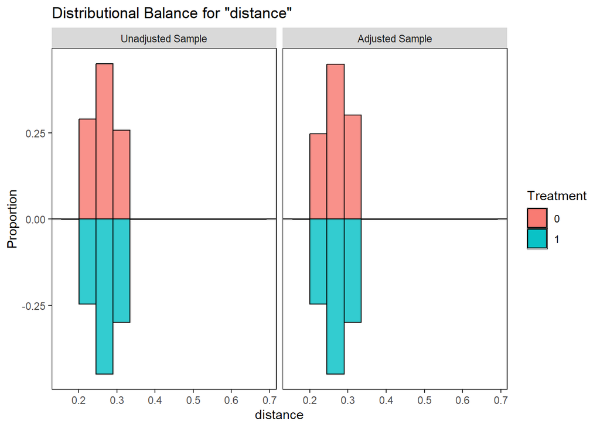

```r
# COMPROBAR EQUILIBRIO RESULTANTE
bal.plot(m.ps.train.2, var.name = "distance", type = "histogram", which = "both",
    mirror = TRUE)
```

Con este ‘balance plot’, se pretende representar la calidad del emparejamiento entre los grupos de tratados y no tratados. Más concretamente, se representa la comparación entre los individuos tratados y no tratados, antes y después del emparejamiento.

Como se puede apreciar, ya de partida se puede considerar que las distribuciones son muy parecidas, si bien es cierto que una vez realizado el emparejamiento con el método matching, las distribuciones entre individuos tratados y no tratados es prácticamente idéntica.

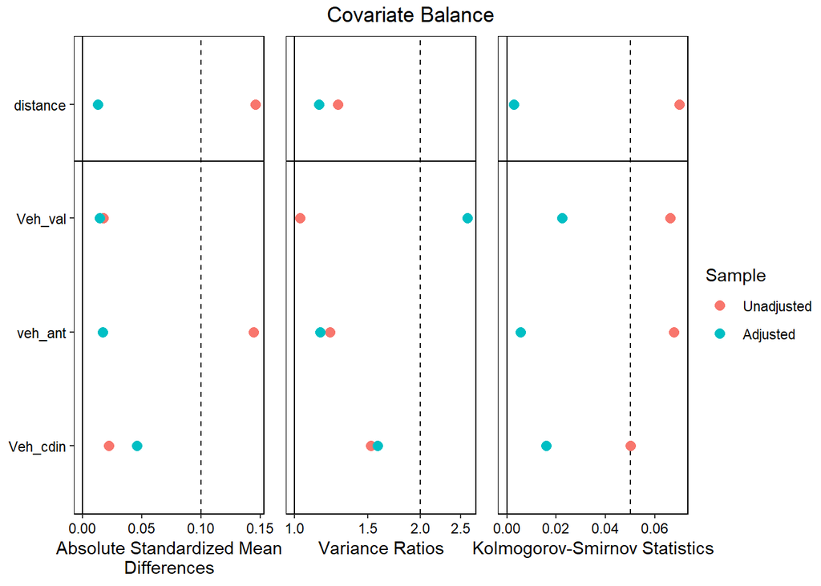

```r
# Graficamente
love.plot(m.ps.train.2, stats = c("m", "var", "ks"), abs = TRUE, thresholds = c(m = 0.1,
    ks = 0.05, var = 2), bin = "std")
```

```r
# # Tabular bal.tab(m.ps.train.1,stats =
# c('m','var','ks'),thresholds=c(m=0.1,ks=0.05,var=2))
```

Con este gráfico, se muestra 3 estadísticos, antes y después del emparejamiento.

Con la primera representación, se muestra la diferencia en promedio entre las variables de los grupos tratados y no tratados. Se observa que una vez realizado el emparejamiento, la media de la diferencia en las variables se acerca a 0, todas por debajo del umbral establecido.

Con la segunda representación, se muestra las relaciones en varianza entre tratados y no tratados. En este caso, como en el anterior, las diferencias en varianza entre tratados y no tratados para las covariables seleccionadas se ven reducidas a niveles aceptables, a excepción de la variable Veh_val, donde aumenta la diferencia en varianza una vez realizado el pareamiento.

En último lugar, con la tercera representación, se muestran resultados del test Kolmogorov-Smirnov, antes y después del emparejamiento. Con un valor menor de 0.05, hace referencia a que no hay suficiente evidencia para afirmar que las distribuciones no se asemejan lo suficiente. Por tanto, para el caso de estudio, se puede afirmar que no existen diferencias relevantes entre las distribuciones de las covariables una vez realizado el método matching.

Ahora, de manera análoga al caso anterior, se procede a obtener un modelo que permita ver la respuesta de nuestros datos frente al tratamiento aplicado.

```r
data.ps2 <- match.data(m.ps.train.2)

fit.ps2 <- lm(accidente ~ experiencia * (Veh_val + veh_ant), data = data.ps2, weights = weights)
```

Se predice la respuesta

```r
library(marginaleffects)
rdos.ps2 <- predictions(fit.ps2,
                       variables = "experiencia",
                       vcov = ~subclass,   # estimacion robusta de se
                       newdata = subset(data.ps2, train == 1),
                       wts = "weights",
                       by="experiencia")
summary(rdos.ps2)
```

```
 experiencia Estimate Std. Error  z Pr(>|z|)  2.5 % 97.5 %
           0   0.1120    0.00447 25   <0.001 0.1033  0.121
           1   0.0969    0.00421 23   <0.001 0.0887  0.105

Columns: experiencia, estimate, std.error, statistic, p.value, conf.low, conf.high
```

De este modo, de nuevo, a pesar de que ambos valores son muy pequeños debido a que para la mayoría de polizas la variable accidentes toma valor 0, se aprecia una diferencia entre la media de accidentes tenidos por ambos grupos si se contempla un p-valor de 0.05, dado por el propio test. Así, se obtiene que aquellos individuos que cuentan con muchos años de experiencia, tienen menos accidentes que aquellos con menos experiencia.

## 3.1 Estimación del efecto y validación

Primero se estiman como son los efectos del tratamiento, para ello se hace uso de una t de Student.

```r
t.test(accidente ~ experiencia, data)
```

```
    Welch Two Sample t-test

data:  accidente by experiencia
t = 3.9076, df = 13055, p-value = 9.37e-05
alternative hypothesis: true difference in means between group 0 and group 1 is not equal to 0
95 percent confidence interval:
 0.009845805 0.029666138
sample estimates:
mean in group 0 mean in group 1
     0.11669855      0.09694258
```

Se evalúa, para ello ser recupera tanto el ATT como el ATE.

```r
data.ps2 <- data.ps2 %>%
    mutate(ipw = case_when(experiencia == 1 ~ 1/(distance), experiencia == 0 ~ 1/(1 -
        distance)), ipw_att = case_when(experiencia == 1 ~ 1, experiencia == 0 ~
        distance/(1 - distance)))


# Estimamos efecto ATE
lm.ps.ate2 <- lm(accidente ~ experiencia, data = data.ps2, weights = ipw)

summary(lm.ps.ate2)
```

```
Call:
lm(formula = accidente ~ experiencia, data = data.ps2, weights = ipw)

Weighted Residuals:
    Min      1Q  Median      3Q     Max
-0.2210 -0.1834 -0.1346 -0.1303  7.9296

Coefficients:
             Estimate Std. Error t value Pr(>|t|)
(Intercept)  0.112186   0.005826  19.256   <2e-16 ***
experiencia -0.015392   0.006816  -2.258    0.024 *
---
Signif. codes:  0 '***' 0.001 '**' 0.01 '*' 0.05 '.' 0.1 ' ' 1

Residual standard error: 0.5595 on 13408 degrees of freedom
Multiple R-squared:  0.0003802, Adjusted R-squared:  0.0003056
F-statistic: 5.099 on 1 and 13408 DF,  p-value: 0.02396
```

```r
# Estimamos efecto ATT
lm.ps.att2 <- lm(accidente ~ experiencia, data = data.ps2, weights = ipw_att)

summary(lm.ps.att2)
```

```
Call:
lm(formula = accidente ~ experiencia, data = data.ps2, weights = ipw_att)

Weighted Residuals:
    Min      1Q  Median      3Q     Max
-0.1554 -0.0969 -0.0747 -0.0665  3.9031

Coefficients:
             Estimate Std. Error t value Pr(>|t|)
(Intercept)  0.112667   0.005798  19.431   <2e-16 ***
experiencia -0.015725   0.006800  -2.313   0.0208 *
---
Signif. codes:  0 '***' 0.001 '**' 0.01 '*' 0.05 '.' 0.1 ' ' 1

Residual standard error: 0.2908 on 13408 degrees of freedom
Multiple R-squared:  0.0003987, Adjusted R-squared:  0.0003241
F-statistic: 5.348 on 1 and 13408 DF,  p-value: 0.02076
```

# 4 Discusión de resultados y conclusiones

Se ha realizado un estudio sobre la influencia del precio de los vehículos y de los años de experiencia, por separado, sobre la posibilidad de sufrir un accidente.

Tras el procesamiento de la cartera de seguros y el análisis exploratorio del conjunto escogido, se ha realizado un emparejamiento de muestras para poder extraer con mayor certeza el efecto del precio y la experiencia sobre los accidentes.